### Machine Learning : Ecoli Data

# Part 1

**The Dataset** : We are using the Ecoli Data Set which has 9 columns Sequence Name, mcg,gvh,lip,chg,aac,alm1,alm2 and Class. We will remove the sequence name as it is unique for each rows and which is not useful for our ML model. And we will perform the operations to predict the class variable. In the data cleaning method we will remove the class having instances less than 10 as given in the report.

#### Tasks

1. Loading the dataset.
2. Cleaning the data including removing classes having instances less than 10.
3. Data visualization.
4. Scale the X variable (independent variable).
5. Make Decision Tree Classifer using GridSearchCV and get the Best Model out of it.
6. Apply same classifier with scaled X variable.
7. Comapre the results

### Importing libraries

All the libraries are imported here

```python
import pandas as pd
import numpy as np
import os
import graphviz
import warnings
#Removing warninga
warnings.filterwarnings('ignore')

#FOR CLASSIFIERS
from sklearn.tree import DecisionTreeClassifier
from sklearn.model_selection import GridSearchCV
from sklearn.svm import SVR
from sklearn.tree import DecisionTreeRegressor
from sklearn.model_selection import cross_val_predict

#TRAIN AND TEST
from sklearn.model_selection import train_test_split

#FOR DECISION TREE
from sklearn import tree
from sklearn.tree import export_graphviz

#GRAPHS
import matplotlib.pyplot as plt
from sklearn.metrics import mean_squared_error

##FEATURE SCALING
from sklearn.preprocessing import StandardScaler

##for confusion matrix and accuracy related library
from sklearn.metrics import confusion_matrix,plot_confusion_matrix,accuracy_score,classification_report,f1_score

#for interactive graph
import seaborn as sns
```

### Reading file

```python
try:
    data  = pd.read_csv('ecoli.data',names = ['Sequence Name','mcg','gvh','lip','chg','aac','alm1','alm2','Class'],delim_whitespace=True)
except:
    print("File  error")
```

### Loading the dataset

We have loaded the dataset after removing the null values (even though there is no null values) but in case if we get any null values.

```python
file = data
file = file.dropna() #DROP IF IS THERE ANY NULL VALUES
```

### The Dataset

```python
file.head()
```

|  | Sequence Name | mcg | gvh | lip | chg | aac | alm1 | alm2 | Class |
| --- | --- | --- | --- | --- | --- | --- | --- | --- | --- |
| 0 | AAT_ECOLI | 0.49 | 0.29 | 0.48 | 0.5 | 0.56 | 0.24 | 0.35 | cp |
| 1 | ACEA_ECOLI | 0.07 | 0.40 | 0.48 | 0.5 | 0.54 | 0.35 | 0.44 | cp |
| 2 | ACEK_ECOLI | 0.56 | 0.40 | 0.48 | 0.5 | 0.49 | 0.37 | 0.46 | cp |
| 3 | ACKA_ECOLI | 0.59 | 0.49 | 0.48 | 0.5 | 0.52 | 0.45 | 0.36 | cp |
| 4 | ADI_ECOLI | 0.23 | 0.32 | 0.48 | 0.5 | 0.55 | 0.25 | 0.35 | cp |

### Data description before removing instances

```python
file.shape
```

```
(336, 9)
```

> Total we have 336 rows and 9 columns in our dataset, before removing instances.

### Method for removing class

Here we will remove the classes having instances less than 10

```python
def removeClass(file):
    x = file

    print(x['Class'].value_counts())
    print("--------------------------")

    #getting indexes
    indexes = x['Class'].value_counts().index.values
    #values of index
    values =  x['Class'].value_counts().values
    l=[]
    #removing the number of instance of class less than 10
    print("We are removing the following classes given below as the number of instances are less than 10\n")
    for i in range(0,len(indexes)):
        if(values[i] < 10):
            l.append(indexes[i])
            indexNames = x[(x['Class'] == indexes[i])].index
            x.drop(indexNames , inplace=True)
            print(indexNames)
    print("\n---Class removed----")
    print(l)
    return x
y = removeClass(file)
```

```
cp     143
im      77
pp      52
imU     35
om      20
omL      5
imS      2
imL      2
Name: Class, dtype: int64
--------------------------
We are removing the following classes given below as the number of instances are less than 10

Int64Index([279, 280, 281, 282, 283], dtype='int64')
Int64Index([220, 221], dtype='int64')
Int64Index([222, 223], dtype='int64')

---Class removed----
['omL', 'imS', 'imL']
```

### Data Description after removing selected instances

```python
print(y.shape)
y.head()
```

```
(327, 9)
```

|  | Sequence Name | mcg | gvh | lip | chg | aac | alm1 | alm2 | Class |
| --- | --- | --- | --- | --- | --- | --- | --- | --- | --- |
| 0 | AAT_ECOLI | 0.49 | 0.29 | 0.48 | 0.5 | 0.56 | 0.24 | 0.35 | cp |
| 1 | ACEA_ECOLI | 0.07 | 0.40 | 0.48 | 0.5 | 0.54 | 0.35 | 0.44 | cp |
| 2 | ACEK_ECOLI | 0.56 | 0.40 | 0.48 | 0.5 | 0.49 | 0.37 | 0.46 | cp |
| 3 | ACKA_ECOLI | 0.59 | 0.49 | 0.48 | 0.5 | 0.52 | 0.45 | 0.36 | cp |
| 4 | ADI_ECOLI | 0.23 | 0.32 | 0.48 | 0.5 | 0.55 | 0.25 | 0.35 | cp |

> We have 327 rows in the dataset and 9 columns now

### Data visualization

```
array([[<AxesSubplot:title={'center':'mcg'}>,
        <AxesSubplot:title={'center':'gvh'}>,
        <AxesSubplot:title={'center':'lip'}>],
       [<AxesSubplot:title={'center':'chg'}>,
        <AxesSubplot:title={'center':'aac'}>,
        <AxesSubplot:title={'center':'alm1'}>],
       [<AxesSubplot:title={'center':'alm2'}>, <AxesSubplot:>,
        <AxesSubplot:>]], dtype=object)
```

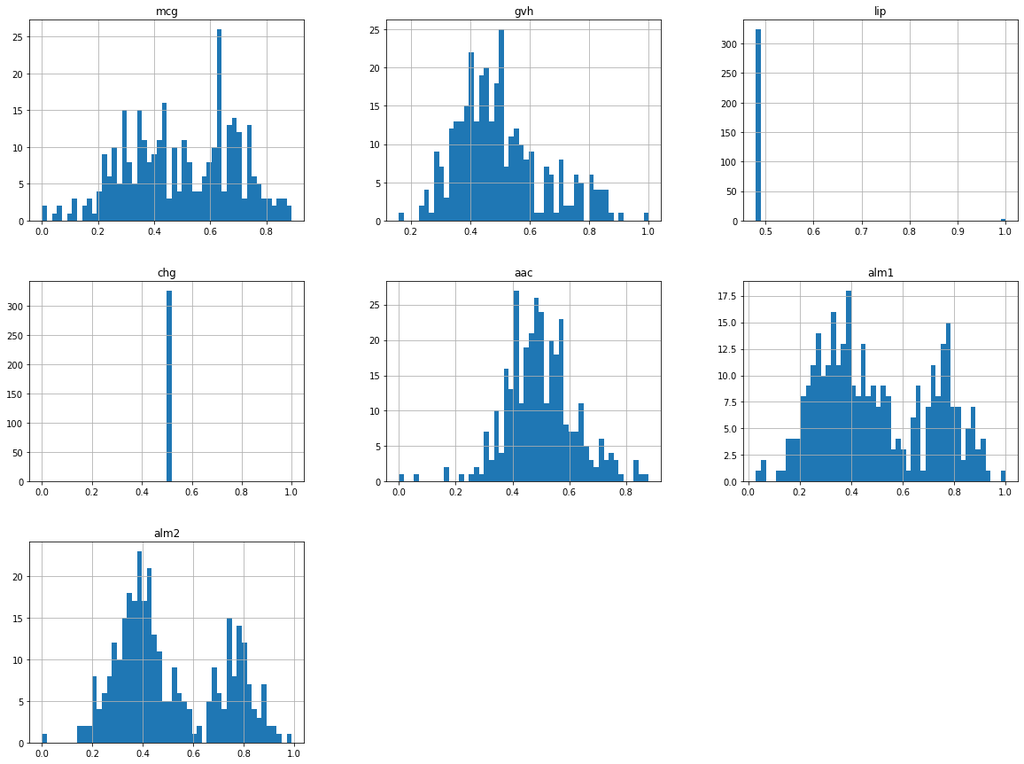

```python
y.hist(bins=50,figsize=(20,15))
```

```
AxesSubplot(0.125,0.125;0.775x0.755)
```

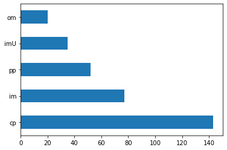

```python
print(y['Class'].value_counts().plot(kind='barh'))
```

### Scatter plot

Using Seaborn

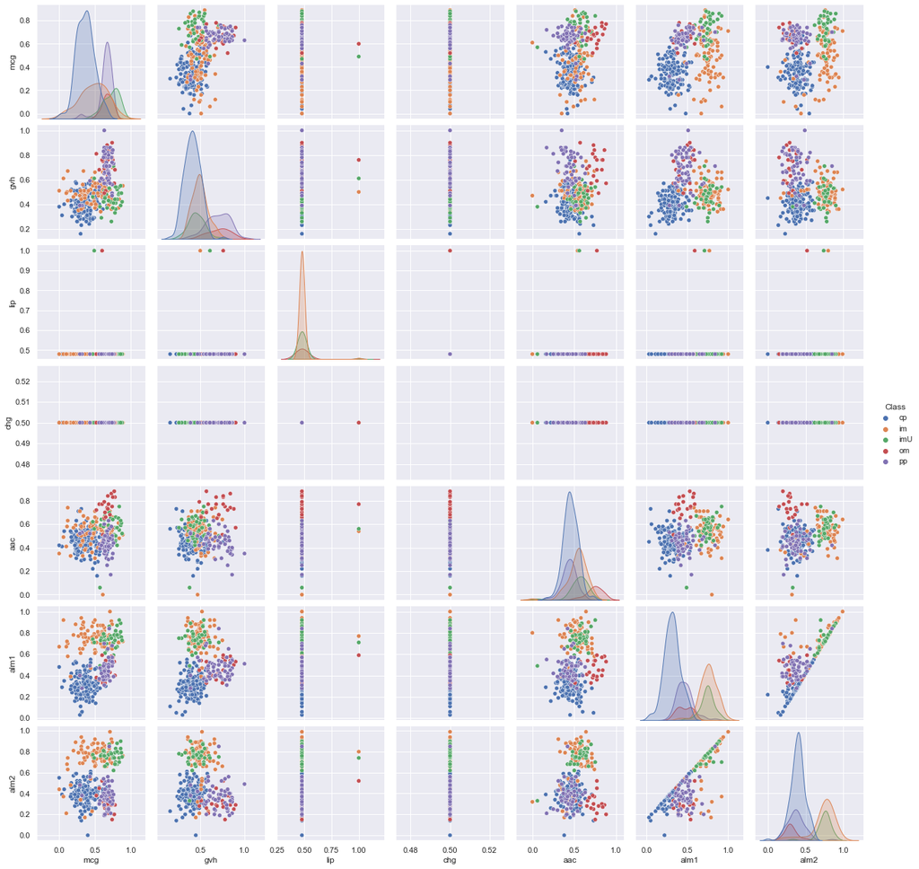

```python
##scatter matrix using seaborn for better visualization
sns.set();
##classify the data points on the basis of class values
sns.pairplot(y, hue='Class');
```

### Independent and dependent variables

To create machine learning model we need independent varibles which predicts the dependent variable. So, while training the model we need both the variables.

```python
#putting only class
dependent_variable = y[['Class']]

#putting all the other columns apart from class
independent_variables = y.iloc[:,1:8]

#keeping independent variales in X_train and dependent variables in Y_train
X_train = independent_variables
Y_train = dependent_variable
print("X values")
print(X_train)
print("Y values")
print(Y_train)
```

```
X values
      mcg   gvh   lip  chg   aac  alm1  alm2
0    0.49  0.29  0.48  0.5  0.56  0.24  0.35
1    0.07  0.40  0.48  0.5  0.54  0.35  0.44
2    0.56  0.40  0.48  0.5  0.49  0.37  0.46
3    0.59  0.49  0.48  0.5  0.52  0.45  0.36
4    0.23  0.32  0.48  0.5  0.55  0.25  0.35
..    ...   ...   ...  ...   ...   ...   ...
331  0.74  0.56  0.48  0.5  0.47  0.68  0.30
332  0.71  0.57  0.48  0.5  0.48  0.35  0.32
333  0.61  0.60  0.48  0.5  0.44  0.39  0.38
334  0.59  0.61  0.48  0.5  0.42  0.42  0.37
335  0.74  0.74  0.48  0.5  0.31  0.53  0.52

[327 rows x 7 columns]
Y values
    Class
0      cp
1      cp
2      cp
3      cp
4      cp
..    ...
331    pp
332    pp
333    pp
334    pp
335    pp

[327 rows x 1 columns]
```

#### Independent and dependent variables

> Our dependent variable is Y which will be used to predict the output using our model and rest all the attributes will be the independent variables. While making the model **using GridSearch we do not need to make the test set** because the **function itself will create the test set with it's fold which is cv.**  
> cv=3 means the data will be divided into 3 sets and each set will be a test set once in each iteration, we will see it in the following step while making the classifer.

### 1. Decision tree Classifier

We are implementing the classifer with the raw value(unscaled) and then we make one more classifier with the scaled value in the next step.

#### Decision Tree Regressor

> ```
>     1. max_depth = create nodes
>     2. creation = gets the index value. gini or entropy
>     3. min_sample_leaf= minimun leaf on each node
> ```

#### Unscaled

```python
tree_clf = DecisionTreeClassifier()
param_grid={'max_depth': [2, 3, 4],'criterion': ['gini','entropy'],'min_samples_leaf': [1,2,3]}
gs=GridSearchCV(tree_clf,param_grid, cv=3)
gs.fit(X_train, dependent_variable)


Y_train_pred = cross_val_predict(gs, X_train, Y_train, cv=3)

best_params=gs.best_params_
accuracy=gs.best_score_

print("Best model",best_params)
```

```
Best model {'criterion': 'gini', 'max_depth': 4, 'min_samples_leaf': 3}
```

#### Explanation

> The above Best Model consist of the best hyperparameters selected by the GridSearchCV from 3 folds. So, this says in 3 iteratation which are the best hyperparameters which generates the best output. **best_patams_** provides the best hyperparameters for the model.

#### Scaled (feature scaling)

Why feature scaling? We are using feature scaling to get a proper euclidean distance which will help us to get a proper result for our model We will be using StandardScaler and use fit_transform() for feature selection fit_transform() will autometically transform the values after fitting it into our model.

We don't need to scale the Y value here.

```python
ss = StandardScaler()

#X_train and X_test holds the numerical values with wide range
X_train_scaled = ss.fit_transform(X_train)

## describing the standard scalar model
print("---------Train set-------")
print(pd.DataFrame(X_train_scaled).describe())


#MAKING CLASSIFER FOR SCALED DATA
tree_clf_scaled = DecisionTreeClassifier()
param_grid={'max_depth': [2, 3, 4],'criterion': ['gini','entropy'],'min_samples_leaf': [2, 3,4]}
gs_scaled=GridSearchCV(tree_clf_scaled,param_grid, cv=3)
gs_scaled.fit(X_train_scaled, Y_train)

#best classifier
best_params_scaled=gs_scaled.best_params_
accuracy_scaled=gs_scaled.best_score_

#PREDICTING Y VALUES
#Y_pred_scaled=gs_scaled.predict(X_test_scaled)
Y_train_pred_scaled = cross_val_predict(gs_scaled, X_train_scaled, Y_train, cv=3)
print("\nBest model",best_params_scaled)
```

```
---------Train set-------
                  0             1             2      3             4  \
count  3.270000e+02  3.270000e+02  3.270000e+02  327.0  3.270000e+02
mean   1.602524e-16 -5.357590e-16  6.319274e-16    0.0 -2.098220e-16
std    1.001533e+00  1.001533e+00  1.001533e+00    0.0  1.001533e+00
min   -2.554980e+00 -2.270723e+00 -9.622504e-02    0.0 -4.061338e+00
25%   -7.971664e-01 -6.675714e-01 -9.622504e-02    0.0 -6.460541e-01
50%   -2.166041e-02 -1.999854e-01 -9.622504e-02    0.0 -7.684016e-02
75%    8.313962e-01  4.679945e-01 -9.622504e-02    0.0  5.736901e-01
max    2.046356e+00  3.340308e+00  1.039230e+01    0.0  3.094495e+00

                  5             6
count  3.270000e+02  3.270000e+02
mean  -3.598888e-17  1.507459e-16
std    1.001533e+00  1.001533e+00
min   -2.154195e+00 -2.434877e+00
25%   -7.717110e-01 -7.410301e-01
50%   -2.187172e-01 -3.538652e-01
75%    9.794360e-01  1.001212e+00
max    2.315838e+00  2.356289e+00

Best model {'criterion': 'gini', 'max_depth': 3, 'min_samples_leaf': 3}
```

#### Explanation

> The above Best Model consist of the best hyperparameters for the scaled model.

### Visualization Raw vs Scales X

Before scaling

```
----------------Raw(before scaled)----------------
```

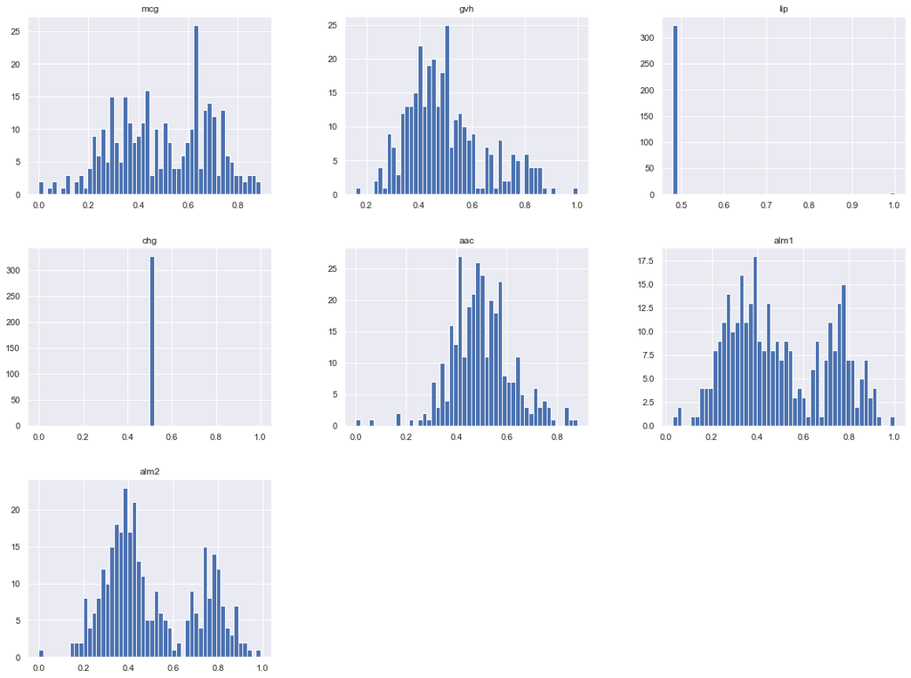

```python
print("----------------Raw(before scaled)----------------")
y.hist(bins=50,figsize=(20,15));
```

After scaling

```
----------------Scaled----------------
```

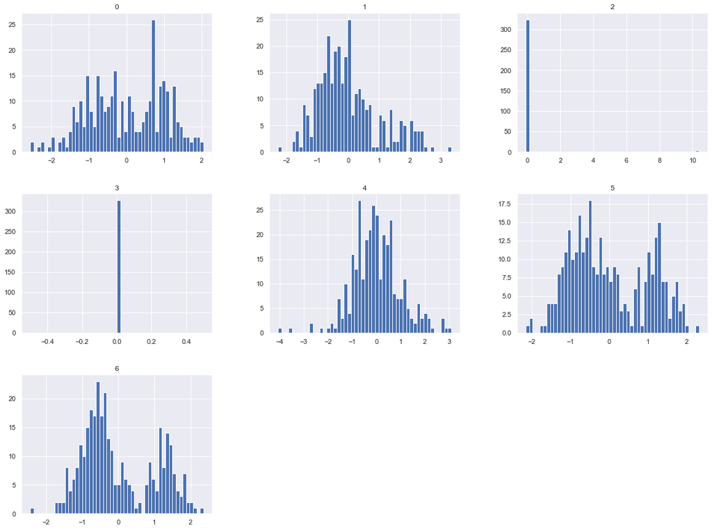

```python
print("----------------Scaled----------------")
pd.DataFrame(X_train_scaled).hist(bins=50,figsize=(20,15));
```

### Explanation

> From both the graph we can see our data has been scaled properly

### F1 score and confusion matrix

```python
print("For unscaled")
print("F1 score:",round(f1_score(Y_train, Y_train_pred, average='micro')*100,3),"%")

print("For scaled")
print("F1 score:",round(f1_score(Y_train, Y_train_pred_scaled, average='micro')*100,3),"%")

print("\n---Confusion matrix plot---\n")
print("Unscaled")
print(confusion_matrix(Y_train, Y_train_pred))
print("\nScaled")
print(confusion_matrix(Y_train, Y_train_pred_scaled))

print("\n-----Classification report------")
print("Unscaled")
print(classification_report(Y_train,Y_train_pred))
print("Scaled")
print(classification_report(Y_train,Y_train_pred_scaled))
```

```
For unscaled
F1 score: 81.957 %
For scaled
F1 score: 81.957 %

---Confusion matrix plot---

Unscaled
[[133   0   0   0  10]
 [  2  63  11   1   0]
 [  1  18  16   0   0]
 [  2   1   0  13   4]
 [  4   3   1   1  43]]

Scaled
[[131   0   0   0  12]
 [  2  64  11   0   0]
 [  1  16  18   0   0]
 [  2   2   0  12   4]
 [  4   3   1   1  43]]

-----Classification report------
Unscaled
              precision    recall  f1-score   support

          cp       0.94      0.93      0.93       143
          im       0.74      0.82      0.78        77
         imU       0.57      0.46      0.51        35
          om       0.87      0.65      0.74        20
          pp       0.75      0.83      0.79        52

    accuracy                           0.82       327
   macro avg       0.77      0.74      0.75       327
weighted avg       0.82      0.82      0.82       327

Scaled
              precision    recall  f1-score   support

          cp       0.94      0.92      0.93       143
          im       0.75      0.83      0.79        77
         imU       0.60      0.51      0.55        35
          om       0.92      0.60      0.73        20
          pp       0.73      0.83      0.77        52

    accuracy                           0.82       327
   macro avg       0.79      0.74      0.75       327
weighted avg       0.82      0.82      0.82       327
```

# Part 2

In project 2 we have Concrete Slump Test Data Set and the dataset conatins 7 Input variables :Cement,Slag,Fly ash,Water,SP, Coarse Aggr and Fine Aggr and 3 Output variables: SLUMP (cm), FLOW (cm) and Compressive Strength (Mpa) but we will remove SLUMP (cm) and FLOW (cm) as we are only predicting Compressive Strength. We will use dropna() inorder to remove the null values(if any) however in the data description it is given that the dataset does not contain any null values.

#### Tasks

1. Read the file
2. Data Cleaning
3. Data visualization
4. Implement Decision tree regressor on unscaled data
5. Implement Decision tree regressor on scaled data
6. Implement Support Vactor Regressor on scaled data
7. Compare the results and make plots to see the difference between the Y value and the Y predicted value

#### Reading file

```python
try:
    file2  = pd.read_csv('slump_test.data')
    file2 = file2.dropna()
except:
  print("File2  error")
```

```python
print(file2.info())
```

```
<class 'pandas.core.frame.DataFrame'>
Int64Index: 103 entries, 0 to 102
Data columns (total 11 columns):
 #   Column                              Non-Null Count  Dtype
---  ------                              --------------  -----
 0   No                                  103 non-null    int64
 1   Cement                              103 non-null    float64
 2   Slag                                103 non-null    float64
 3   Fly ash                             103 non-null    float64
 4   Water                               103 non-null    float64
 5   SP                                  103 non-null    float64
 6   Coarse Aggr.                        103 non-null    float64
 7   Fine Aggr.                          103 non-null    float64
 8   SLUMP(cm)                           103 non-null    float64
 9   FLOW(cm)                            103 non-null    float64
 10  Compressive Strength (28-day)(Mpa)  103 non-null    float64
dtypes: float64(10), int64(1)
memory usage: 9.7 KB
None
```

### Data cleaning

We removed the 'No' column as it shows unique numbers in each row(Serial number) because unique values are not useful for machine learnig operations and also will remove the SLUMP (cm), FLOW (cm) as we are not predicting these variables. Will implement dropna() to drop the null values however the dataset does not contain any null values given in the data secriptionfile.  
**df is our new dataset now for further operartions**

```python
file2 = file2.dropna()
df = file2.iloc[:,[1,2,3,4,5,6,7,10]]
df.info()
```

```
<class 'pandas.core.frame.DataFrame'>
Int64Index: 103 entries, 0 to 102
Data columns (total 8 columns):
 #   Column                              Non-Null Count  Dtype
---  ------                              --------------  -----
 0   Cement                              103 non-null    float64
 1   Slag                                103 non-null    float64
 2   Fly ash                             103 non-null    float64
 3   Water                               103 non-null    float64
 4   SP                                  103 non-null    float64
 5   Coarse Aggr.                        103 non-null    float64
 6   Fine Aggr.                          103 non-null    float64
 7   Compressive Strength (28-day)(Mpa)  103 non-null    float64
dtypes: float64(8)
memory usage: 7.2 KB
```

#### Explanation

> Now we have 7 input variables :**Cement, Slag, Fly ash, Water, SP, Coarse Aggr and Fine Aggr (independent variable)** and 1 output variable (dependent variable) which is Compressive Strength.  
> And we will perform regression operations on the Compressive Strength

### Data visualization

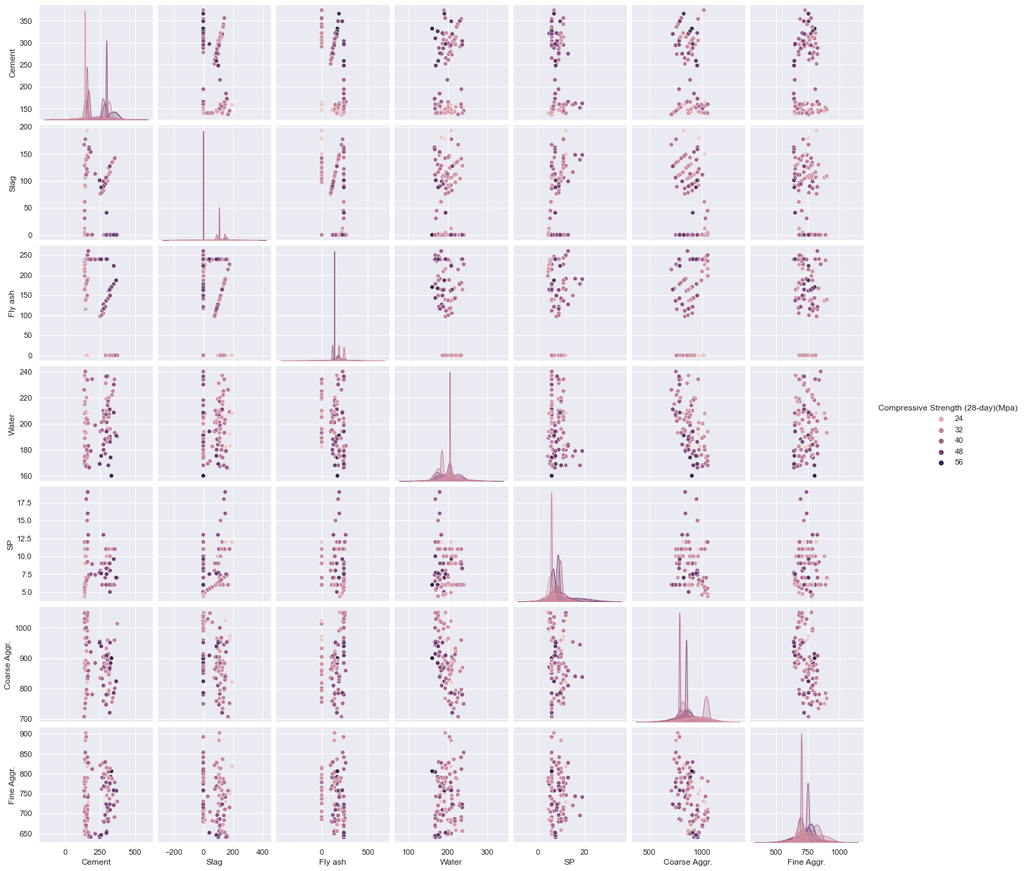

```python
#pd.plotting.scatter_matrix(df, alpha=0.2,figsize=(15,15));
##scatter matrix using seaborn for better visualization
sns.set();

##classify the data points on the basis of class values
sns.pairplot(df,hue='Compressive Strength (28-day)(Mpa)');
```

#### Explanation

> 1. Compressive strength increases when we have **slag 0 and higher value of cement** in KG.
> 2. Higher value of **Fly ash** and higher value of **cement** makes strongest compressive strength.
> 3. **Water level=200** and **Fly ash=0** makes poorest compressive strength.

### Creating input and output variables

```python
input_variables = df.iloc[:,0:7]
output_variables = df.iloc[:,7:]

X_train_p2 = input_variables
Y_train_p2 = output_variables

print("Input variables",input_variables.columns)
print("Output variables",output_variables.columns)
```

```
Input variables Index(['Cement', 'Slag', 'Fly ash', 'Water', 'SP', 'Coarse Aggr.',
       'Fine Aggr.'],
      dtype='object')
Output variables Index(['Compressive Strength (28-day)(Mpa)'], dtype='object')
```

### Scaling

```python
ss_p2 = StandardScaler()
X_train_scaled_p2 = ss_p2.fit_transform(X_train_p2) #X_train and X_test holds the numerical values with wide range
```

#### Explanation

> We have scaled out X variable and will use the variable for Decision Tree Regressor and for Support Vactor Regressor. We have used **StandardScalar() and fit_transform()** to scale the data.

### Visualization Raw data and Scaled data

Raw data

```
----------------Raw(before scaled)----------------
```

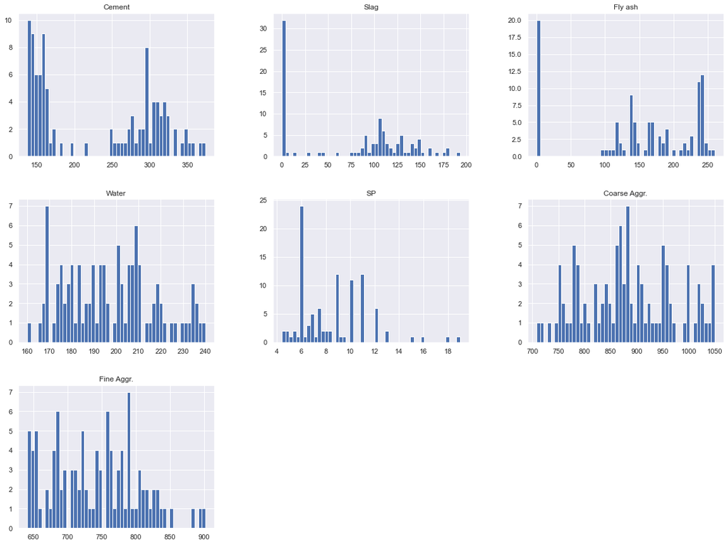

```python
print("----------------Raw(before scaled)----------------")
input_variables.hist(bins=50,figsize=(20,15));
```

Scaled

```
----------------Scaled----------------
```

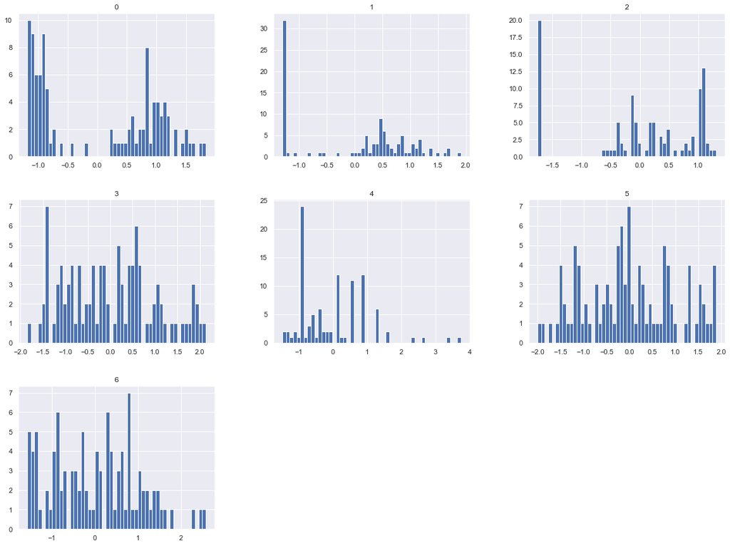

```python
print("----------------Scaled----------------")
pd.DataFrame(X_train_scaled_p2).hist(bins=50,figsize=(20,15));
```

### Explanation

> From the above visualization of X raw and X scaled value we can see out data has been properly scaled as the patters are same in the both.

### Function for Regressor

Here we have to call the function thrice.

1. First fucntion will be called for Decision Tree Regressor for unscaled data and will pass classifier name,input_variables,output_variables (unscaled) in this function.
2. Second function will call the Decision Tree Regressor scaled data and will pass classifier name,input_variables,output_variables in this function. Here,the input_variable is scaled.
3. Third function will call the Support Vactor Regressor for the scaled data and will pass classifier name,input_variables,output_variables in this function. Here, the input_variable is scaled.

**To run the fucntion it is important to pass the right paramaters**

```
Decision Tree Regressor unscaled
Best model: {'criterion': 'mse', 'max_depth': 3, 'min_samples_leaf': 4}
Mean squared error 24.19376144325782
-----------------
```

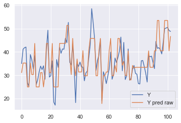

```
Decision Tree Regressor scaled
Best model: {'criterion': 'mse', 'max_depth': 3, 'min_samples_leaf': 4}
Mean squared error 24.253533530636464
-----------------
```

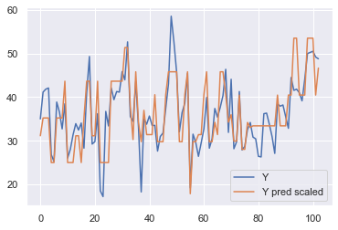

```
Support Vactor Regressor scaled
Best model: {'C': 0.1, 'gamma': 0.1, 'kernel': 'linear', 'max_iter': 100}
Mean squared error 29.917442996386438
-----------------
```

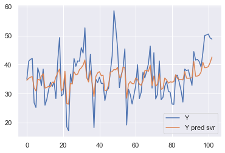

```python
def runPartTwo(classifier,input_variables,output_variables,scaled):

    if classifier == "DecisionTreeRegressor":

        #CREATING TEST AND TRAIN SET
        X_train_p2 = input_variables
        Y_train_p2 = output_variables

        #1. Decision tree regressor
        tree_clf_p2 = DecisionTreeRegressor()
        param_grid={'max_depth': [2, 3, 4],'criterion':['mse'],'min_samples_leaf': [2, 3,4]}
        gs_p2=GridSearchCV(tree_clf_p2,param_grid, cv=3)
        gs_p2.fit(X_train_p2, Y_train_p2)



        if scaled == True :
            Y_pred_scaled_p2 = cross_val_predict(gs_p2, X_train_p2, Y_train_p2, cv=3)
            best_params_p2=gs_p2.best_params_ #FINDING BEST MODEL
            accuracy_p3=gs_p2.best_score_ #ACCURACY SCORE

            print("Decision Tree Regressor scaled")
            print("Best model:",best_params_p2)
            print("Mean squared error",mean_squared_error(Y_train_p2, Y_pred_scaled_p2))
            print("-----------------\n")

            plt.plot(Y_train_p2.to_numpy())
            plt.plot(Y_pred_scaled_p2)
            plt.legend(['Y', 'Y pred scaled'], loc=4)
            plt.show()

        else:
            Y_pred_p2 = cross_val_predict(gs_p2, X_train_p2, Y_train_p2, cv=3)
            best_params_p2=gs_p2.best_params_ #FINDING BEST MODEL
            accuracy_p3=gs_p2.best_score_ #ACCURACY SCORE

            print("Decision Tree Regressor unscaled")
            print("Best model:",best_params_p2)
            print("Mean squared error",mean_squared_error(Y_train_p2, Y_pred_p2))
            print("-----------------\n")

            plt.plot(Y_train_p2.to_numpy())
            plt.plot(Y_pred_p2)
            plt.legend(['Y', 'Y pred raw'], loc=4)
            plt.show()


    #2. Support vactor regressor
    elif classifier == "SupportVactorRegressor":

        if scaled == True:
            #CREATING TEST AND TRAIN SET
            X_train_p2 = input_variables
            Y_train_p2 = output_variables
            svr = SVR()
            param_grid={'kernel':['rbf','linear'],'C':[0.1,0.001],'gamma': [0.1,0.01],'max_iter':[100,1000]}
            gs_scaled_p2_svr=GridSearchCV(svr ,param_grid, cv=3)
            gs_scaled_p2_svr.fit(X_train_scaled_p2, Y_train_p2);
            Y_pred_svr = cross_val_predict(gs_scaled_p2_svr, X_train_scaled_p2, Y_train_p2, cv=3)
            best_params_svr=gs_scaled_p2_svr.best_params_
            accuracy_svr=gs_scaled_p2_svr.best_score_

            print("Support Vactor Regressor scaled")
            print("Best model:",best_params_svr)
            #print("Accuracy",round(accuracy_svr*100,3),"%")
            print("Mean squared error",mean_squared_error(Y_train_p2, Y_pred_svr))
            print("-----------------\n")

            plt.plot(Y_train_p2.to_numpy())
            plt.plot(Y_pred_svr)
            plt.legend(['Y', 'Y pred svr'], loc=4)
            plt.show()

        else:
            print("Pass scaled values!!!")
    else:
        print("Please pass given paramenetrs")


runPartTwo("DecisionTreeRegressor",input_variables,output_variables,False) #PASSING RAW VALUE WITHOUT SCALED
runPartTwo("DecisionTreeRegressor",X_train_scaled_p2,output_variables,True) #PASSING SCALED VALUE
runPartTwo("SupportVactorRegressor",X_train_scaled_p2,output_variables,True) #PASSING SCALED VALUE
```

### Explanation

#### Decision Tree Regressor

> ```
>     1. max_depth = create nodes
>     2. creation = gets the index value
>     3. min_sample_leaf= minimun leaf on each node
> ```

#### Support Vactor Regressor

> ```
>     1. kernel = mathematical function wheather we use polynomial, linear or rbf
>     2. C = Regularization parameter
>     3. gamma = Kernel coefficient
>     4. max_iter = iteration while running the model
> ```

> 1. We have passed 'kernel':['rbf','linear'],'C':[0.1,0.001],'gamma': [0.1,0.01],'max_iter':[100,1000] in our model for Support Vactor Regressor.
> 2. For Decision Tree Regressor we have passed 'max_depth': [2, 3, 4],'criterion':['mse'],'min_samples_leaf': [2, 3,4] as the hyperparamater.
> 3. GrideSearchCV provides the best hyperparameters which generates the best output by using **best_params_** 4.**The mean square error of scaled and the unscaled Decision Tree Regressor are almost the same.**
> 4. **Support Vactor Regressor is havinbg the highest Mean Square Error.**

### Graph plot for Y vs Y Predicted value

> We have used line charts to show the diference between the Y and the Y Predicted value.  
> We have used **plt.legend(['val1','val2'])** to show the proper visualization of Y and Y predicted value with blue and orange color.

### Explanation scaled and unscaled graph Decision Tree Regressor

> There is no much difference between the Y Predicted value of raw data and the scaled data as the mean square error of both the models are almost the same,still this model is better than the Support Vactor Regressor in this case because mean square error of SVR is more.

### Explanation SVR graph

> From the graph below we can see Support vactor regressor does not provide better accuracy for the predicted output because the predicted Y Predicted value using SVR has high varience with the Y value.